# Singapore GDP Growth Time Series Analysis

Author

Claudya Fong

# 1. Introduction

This project analyses Singapore’s GDP growth using time series methods in R, including STL decomposition and ARIMA/ETS modelling. The objective is to understand trend behaviour, evaluate model suitability, and produce short-term forecasts.

# 2. Data Preparation

```r
library(fabletools)
library(ggplot2)
library(readr)
library(tidyverse)
library(tsibble)
library(fpp3)
data <- read_csv("M015631.csv", skip = 10) |>
  na.omit ()
GDP_long <- data |>
  pivot_longer(
    cols = -1,
    names_to = "Quarter",
    values_to = "GDP"
  )

GDP_long$GDP <- as.numeric(GDP_long$GDP)
GR <- GDP_long %>%
  mutate(Quarter = yearquarter(Quarter)) %>%
  as_tsibble(index = Quarter)
```

# 3. Exploratory Analysis

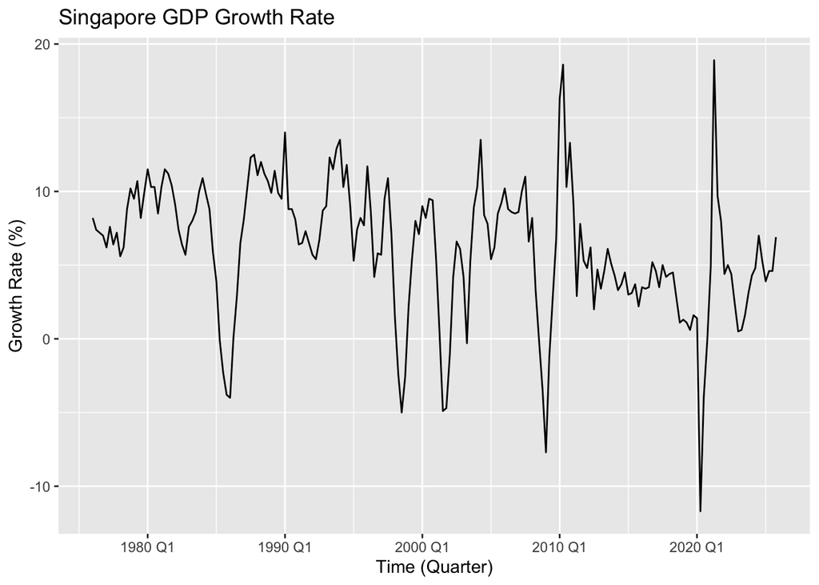

```r
GR |> autoplot(GDP) +
  labs(
     y = "Growth Rate (%)",
     x = "Time (Quarter)",
  title = "Singapore GDP Growth Rate"
  )
```

Since the series is YoY-based, seasonality is expected to be reduced, which aligns with the weak seasonal component observed.

Overall, Singapore’s GDP growth rate shows a mild downward trend over time. Several sharp declines are visible during periods of economic disruption, most notably around 2020 Q1 during the COVID-19 shock.

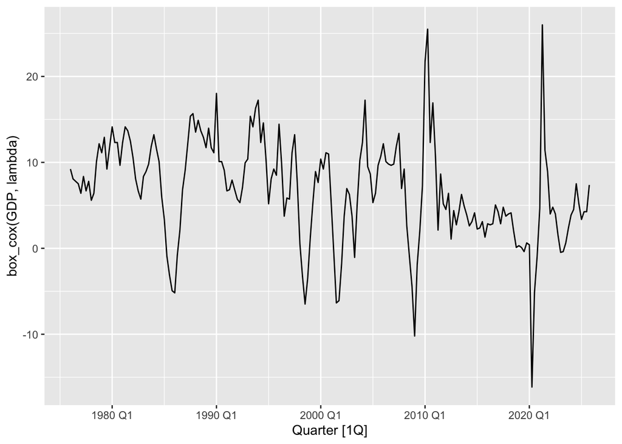

```r
lambda <- GR |> features(GDP, guerrero) |>
  dplyr::pull(lambda_guerrero)
GR |> autoplot(box_cox(GDP, lambda))
```

To assess whether variance-stabilising transformation was needed, the Guerrero method was applied. The suggested Box-Cox parameter was 1.174, which is close to 1, indicating that transformation is not necessary.

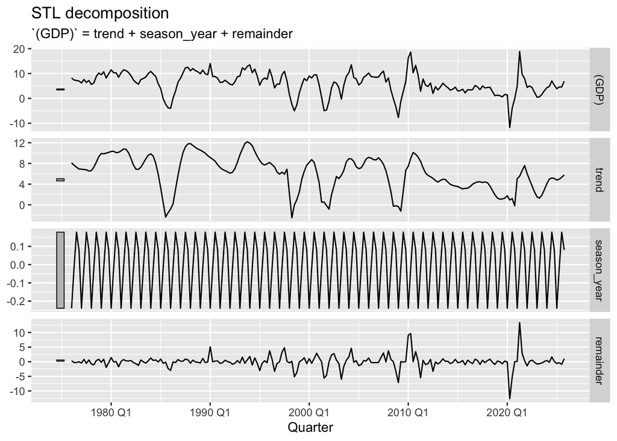

```r
dcmp <- GR |>
  model(stl = STL((GDP) ~ season(window = "periodic"),
                  robust = TRUE))
components(dcmp) |> autoplot()
```

The STL decomposition shows a mild downward trend over time. The seasonal component is weak and relatively stable, which is consistent with the expectation that a YoY series contains limited seasonal variation. The remainder appears largely random, suggesting that most systematic movement has been captured.

# 4. Modelling

```r
Fit <- GR |>
  model(
    auto_ARIMA = ARIMA((GDP), stepwise = FALSE, approx = FALSE),
    auto_ETS = ETS(GDP)
    )
```

```r
glance(Fit) |> arrange(AIC)
```

```
# A tibble: 2 × 11
  .model    sigma2 log_lik   AIC  AICc   BIC ar_roots ma_roots   MSE  AMSE   MAE
  <chr>      <dbl>   <dbl> <dbl> <dbl> <dbl> <list>   <list>   <dbl> <dbl> <dbl>
1 auto_ARI…   5.20   -449.  902.  902.  908. <cpl>    <cpl>    NA     NA   NA
2 auto_ETS    8.90   -747. 1501. 1501. 1511. <NULL>   <NULL>    8.81  18.8  2.09
```

ARIMA is more suitable as the series shows weak seasonality and relies primarily on autocorrelation structure rather than trend smoothing.

This is supported by the model selection criteria. ARIMA appears preferable because it provides a better trade-off between model fit and complexity than ETS. Proven by lower AIC, AICc, and other indicators.

```r
Fit |>
  select(auto_ARIMA) |>
  report()
```

```
Series: GDP
Model: ARIMA(0,1,0)(0,0,1)[4]
Transformation: (GDP)

Coefficients:
         sma1
      -0.8755
s.e.   0.0376

sigma^2 estimated as 5.201:  log likelihood=-448.83
AIC=901.67   AICc=901.73   BIC=908.25
```

The ARIMA model suggests one order of differencing (d = 1), indicating the original series is non-stationary.

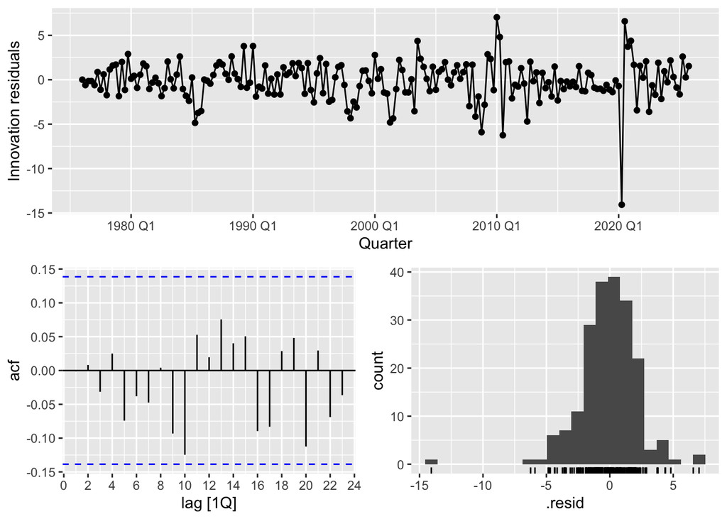

```r
Fit |>
  select(auto_ARIMA) |>
  gg_tsresiduals()
```

The residuals do not appear normally distributed and show left skewness. Clear outliers are also visible around 2020 Q1, likely reflecting the COVID-19 shock.

```r
Fit |>
  select(auto_ARIMA, auto_ETS) |>
  augment() |>
  features(.innov, ljung_box, lag = 24)
```

```
# A tibble: 2 × 3
  .model     lb_stat   lb_pvalue
  <chr>        <dbl>       <dbl>
1 auto_ARIMA    18.6 0.772
2 auto_ETS      74.9 0.000000388
```

# 5. Forecasting

```r
EGR <- GR |>
  model(
    auto_ARIMA = ARIMA((GDP), stepwise = FALSE, approx = FALSE))|>
  forecast(h = 24, level = c(80, 95))
```

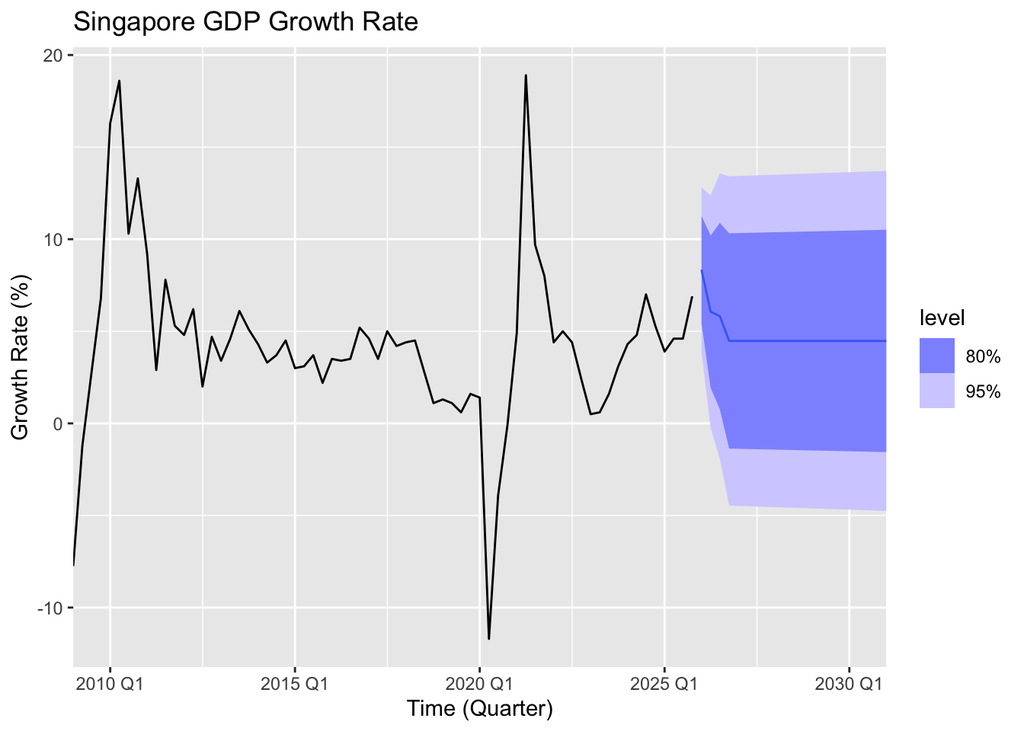

```r
EGR|>
  autoplot(GR) +
  labs(
     y = "Growth Rate (%)",
     x = "Time (Quarter)",
     title = "Singapore GDP Growth Rate") +
  coord_cartesian(xlim = yearquarter(c("2010 Q1", "2030 Q1")))
```

The forecasts suggest a short-term rebound in growth followed by stabilization, indicating cyclical recovery rather than sustained long-term acceleration.

# 6. Conclusion